# Lecture 6

January 29, 2020

## Outline

- Precipitation (continued)
- Frequency analysis
- Climate networks in the U.S.
- Areal Precipitation

## Precipitation

[figure not shown]

- This is a typical precipitation map for the southeastern United States which is produced by the [Southeast Regional Climate Center](https://sercc.com/).
- Anyone know where the SERCC is???
- [Each region](https://www.ncdc.noaa.gov/customer-support/partnerships/regional-climate-centers) of the U.S. has a Climate Center that is tasked with not only observing the weather, but observing and studying long-term climate trends.

## Climate Sites in NC

[figure not shown]

Observations include:

- Temperature (high-low)
- Degree days
- Precipitation
- Snowfall
- Wind speed (max-mean)
- Solar radiation
- Cloudiness
- Relative Humidity

## Frequency Analysis

[figure not shown]

- Intensity: \([L*T^{-1}]\)
- Duration: \([T]\)
- Frequency: \([T^{-1}]\)
- Recurrence: \([T]\)

## Frquency Analysis

[figure not shown]

\(z = \frac{x - \overline{x}}{S_{x}}\)

\(z\): The normalized outcome for which the probability is desired \(x\): Desired Outcome \(\overline{x}\): mean \(S_{x}\): Standard Deviation

Soooo… How many standard deviations are we away from the mean???

## Normal Distribution

[figure not shown]

Standard normal distribution theory says that roughly 68% of population in a normal distribution lies within 1 S.D., 95% within 2 S.Ds, 99% within 3 S.Ds, 99.99% within 4 S.Ds and so on and so forth…

## \(z\) value probability of exceedance and return period

Let’s run some numbers:

```r
df <- data.frame(Year = c(1975:1984), Annual_PPT = c(1020,987,894,1040,995,780,1004,930,1192,950))
df
```

```
##    Year Annual_PPT
## 1  1975       1020
## 2  1976        987
## 3  1977        894
## 4  1978       1040
## 5  1979        995
## 6  1980        780
## 7  1981       1004
## 8  1982        930
## 9  1983       1192
## 10 1984        950
```

## Finding the Exceedance Probability

Let’s check the probability that precipitation will \(\le\) 1,100 mm

Recall: \(z = \frac{x - \overline{x}}{S_{x}}\)

```r
a <- 1100
xBar <- mean(df$Annual_PPT)
stdDev <- sd(df$Annual_PPT)

z <- (a-xBar)/stdDev
z
```

```
## [1] 1.135924
```

## Finding the return period

If we ant to know what amount of precipitation we can expect to exceed every three years:

```r
z <- .404

a <- z * stdDev + xBar
a
```

```
## [1] 1022.163
```

Chances are that precipitation will exceed 1,022 mm once every three years.

## Radar Stations

### [NEXRAD](https://www.youtube.com/watch?v=KdKouCnhvPs)

[figure not shown]

## TDWR

[figure not shown]

## Data Loading

```r
sf <- st_read(here("shp/NC_ppt_stations.shp"))%>%
  st_transform(sf, crs=2958)
sf$ppt <- rnorm(nrow(sf),mean = 3)

catchment <- st_read(here("shp/HUC8.shp"))[6,]%>%
  st_transform(crs = 2958)
pts <- st_crop(sf,catchment)
```

## Arithmetic

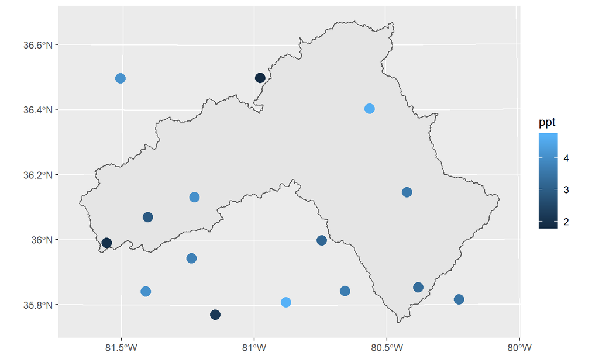

```r
ggplot()+
  geom_sf(data=catchment)+
  geom_sf(data = pts, aes(col = ppt), size = 4)
```

## Thiessen / Voroni Method

```r
union <- st_union(sf) # Turn data frame of polygons into list
voroni <- st_cast(st_voronoi(union))
voroni_sf <- st_as_sf(voroni)%>%
  cbind(sf)
```

[figure not shown]